# U5. Illia y el crecimiento (1963–1966)

Historia Económica Argentina · Clase 20

Sebastian Freille

Universidad Nacional de Córdoba

# Apertura y hoja de ruta

## Dónde quedamos

- El **interregno de Guido** (1962–1963) cerró con recesión, inflación y desempleo cercano al 9 %.
- La ortodoxia no estabilizó; el *stop-and-go* aparecía como un **patrón estructural** no resuelto.
- Hoy analizamos el gobierno de **Arturo Illia**: cómo logró **reactivar y crecer**… y por qué ese crecimiento no se tradujo en estabilidad política.

**Idea clave**

Illia demostró que el *stop-and-go* podía **retrasarse** con una política cambiaria sensata y condiciones favorables, pero la **fragilidad política** de la democracia restringida prevaleció sobre el éxito económico.

## La pregunta de hoy

> ¿Cómo logró Illia **romper temporalmente el ciclo** recesivo? ¿Por qué un gobierno con **crecimiento del 10 %**, inversión del 20 % y superávit comercial fue derrocado en 1966?

## Mapa de la clase

1. **Bloque 1 — Contexto político 1963:** elecciones restringidas y tensiones permanentes.
2. **Bloque 2 — El *stop-and-go*:** herencia recesiva y el mecanismo estructural.
3. **Bloque 3 — Reactivación y resultados:** política fiscal, cambiaria y crecimiento.
4. **Bloque 4 — Contradicciones y fin:** petróleo, desgaste político y golpe de 1966.

# Bloque 1. Contexto político 1963

## [1.1] Elecciones restringidas

- En **julio de 1963** se realizaron elecciones con los candidatos **peronistas proscriptos**.
- **Arturo Illia** (UCRP, línea yrigoyenista) ganó con el **25 %** de los votos.
- El **19 % de votos en blanco** fue la segunda minoría: el peronismo, ausente de la urna, seguía siendo la fuerza más votada del país.

**Gobernar sin mayoría**

Illia asumió con una **legitimidad numérica débil** y dos enemigos poderosos: el sindicalismo peronista y el “partido militar”.

Gerchunoff y Llach (2007), cap. 7.

## [1.2] Tensión permanente

- La relación con la **CGT** fue complicada desde el inicio: tomas de fábricas, paros generales, negociaciones difíciles.
- Los **medios de comunicación** y sectores empresarios presionaban contra el gobierno.
- El **fantasma del golpe** sobrevoló toda la presidencia; hacia mediados de 1966 la tensión era insostenible.

**El dilema de la democracia restringida**

Un sistema que excluye al **40 % del electorado** no puede generar estabilidad política, por más sensata que sea su política económica.

Gerchunoff y Llach (2007), cap. 7; De Pablo (2005), cap. 5.

# Bloque 2. El *stop-and-go*

## [2.1] Herencia recesiva

- Illia asumió tras **dos años de recesión**: desempleo creciente, salario real disminuido, iliquidez y escasez de crédito.
- El corte abrupto de **capital externo** y la política monetaria ortodoxa de Guido habían contraído fuertemente la actividad.
- Entre 1948 y 1963 el PBI per cápita había crecido apenas un 4 % (promedio mundial: 50 %).

Gerchunoff y Llach (2007), cap. 7.

## [2.2] El mecanismo

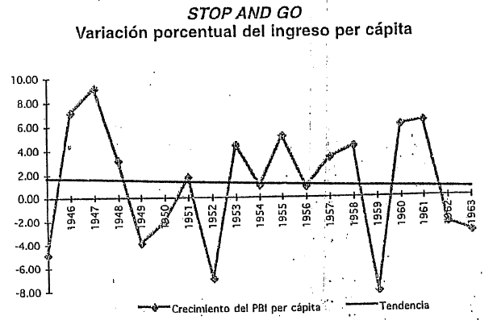

Gerchunoff y Llach (2007), cap. 7.

## [2.3] El desafío: ¿cómo romper el ciclo?

- En condiciones excepcionales —un **flujo sostenido de capital**— podía alterarse la estructura productiva y retrasar el *stop*.
- Frondizi había intentado capitalizar el país por la vía de préstamos e inversiones extranjeras; la recesión de 1962–63 demostró los límites de esa apuesta.
- Illia enfrentaba una pregunta distinta: ¿es posible **crecer sin depender de capitales externos** masivos?

**La apuesta de Illia**

En lugar de buscar capital externo, Illia apostó a **reactivar la demanda interna** y a **recuperar las exportaciones** con un tipo de cambio competitivo pero estable.

Gerchunoff y Llach (2007), cap. 7.

# Bloque 3. Reactivación y resultados

## [3.1] Política de reactivación

| Eje | Medidas |
| --- | --- |
| **Fiscal** | Expansión del gasto público; emisión monetaria para estimular liquidez y crédito |
| **Tarifas** | Congelamiento de tarifas de servicios públicos para mejorar salario real |
| **Salarios** | Ley de Salario Mínimo, Vital y Móvil (1964); crecimiento nominal por encima de la inflación |
| **Deuda** | Renegociación con países acreedores (1965) para aliviar la cuenta capital |
| **Crédito** | Facilitado a industrias intensivas en insumos nacionales; suspensión de financiamiento a importaciones |

- Resultado inmediato: el **salario real creció ~10 %** y el consumo se recuperó.

Gerchunoff y Llach (2007), cap. 7.

## [3.2] Política cambiaria: *crawling peg*

- Se optó por un **ajuste cambiario gradual** (*crawling peg*): nueve devaluaciones pequeñas, no bruscas.
- El objetivo era **mantener la competitividad exportadora** sin generar saltos inflacionarios ni recesivos.
- Ni tipo de cambio fijo ni devaluación traumática: un **camino intermedio** que preservó el poder de compra de los exportadores.

**Innovación cambiaria**

El *crawling peg* de Illia fue uno de los pocos intentos serios de **desinflar sin recesionar** en la historia argentina hasta ese momento.

Gerchunoff y Llach (2007), cap. 7.

## [3.3] Un punto de inflexión en las exportaciones

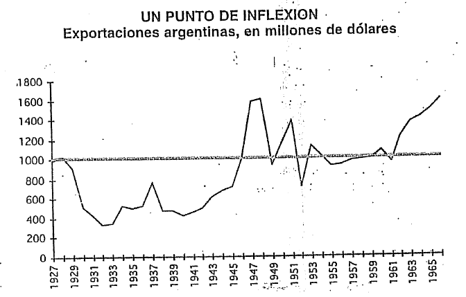

Gerchunoff y Llach (2007), cap. 7.

## [3.4] Boom agropecuario

**¿Suerte o política?**

El *crawling peg* y la recuperación de precios relativos del agro **coincidieron favorablemente**. Pero la política cambiaria fue necesaria para que esa coyuntura se tradujera en divisas.

Gerchunoff y Llach (2007), cap. 7.

## [3.5] Resultados macroeconómicos

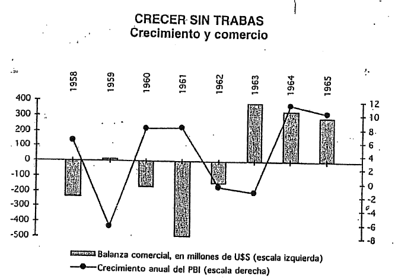

Gerchunoff y Llach (2007), cap. 7.

## [3.6] Crecimiento sin trabas

[output not shown]

- **1964–1965**: crecimiento promedio del **10 %**, inversión cercana al **20 %** del PBI, desempleo reducido a la mitad.
- El saldo comercial 1963–66 fue casi el equivalente a un año total de exportaciones previas.

**Logro inédito**

Por primera vez en más de quince años, la economía creció **sin una crisis de balanza de pagos inmediata**. El *stop-and-go* se había retrasado.

Gerchunoff y Llach (2007), cap. 7; Díaz Alejandro (1970).

## [3.7] La excepción: el petróleo

- Illia anuló los **contratos petroleros con firmas extranjeras** firmados por Frondizi.
- Medida **coherente con su ideología** (nacionalismo yrigoyenista), pero costosa en términos de **credibilidad internacional**.
- Se detuvo bruscamente el crecimiento del sector; reapareció una fuente de **drenaje de divisas** (importación de petróleo).

**Contradicción estructural**

La anulación de los contratos petroleros mostró que incluso un gobierno económicamente exitoso no podía escapar de la **tensión entre nacionalismo y necesidad de capitales**.

Gerchunoff y Llach (2007), cap. 7.

# Bloque 4. Contradicciones y fin

## [4.1] Desgaste político

- A principios de 1966 coexistían una **doble sensación**: crisis política en ciernes… pero **sin crisis económica**.
- Se aludía al deterioro de la balanza de pagos para anticipar recesión, pero el PBI aún crecía y no había crisis cambiaria.
- El fin de Illia estaba cerca por **desgaste político**, no por fracaso económico.

**Economía vs. política**

La caída de Illia **no puede atribuirse a razones de índole económica**. La economía funcionaba; el problema era la **viabilidad de la democracia restringida**.

Gerchunoff y Llach (2007), cap. 7; De Pablo (2005), cap. 5.

## [4.2] El golpe de 1966

- A finales de junio de 1966, los jefes de las tres fuerzas militares declararon el inicio de la **Revolución Argentina**.
- **Juan Carlos Onganía** asumió el poder, cerrando el breve experimento de crecimiento con estabilidad.
- La Revolución Argentina se presentó como una **modernización autoritaria**: estabilización, orden y desarrollo sin conflictos sociales.

**Paradoja**

Argentina derrocó un gobierno que crecía al 10 % anual para instalar una dictadura que prometía… crecimiento y estabilidad.

Gerchunoff y Llach (2007), cap. 7.

## [4.3] Evaluación del gobierno de Illia

| Aspecto | Evaluación |
| --- | --- |
| **Crecimiento** | 10 % en 1964–65, inversión récord, pleno empleo |
| **Balanza de pagos** | Superávits sostenidos; crawling peg funcional |
| **Distribución** | Salario real recuperado; tarifas congeladas |
| **Inflación** | Moderada, no resuelta |
| **Política** | Fracaso institucional; golpe militar |

- Illia demostró que la **restricción externa podía relajarse** con política cambiaria sensata.
- Pero no alcanzó a **transformar la estructura productiva**: la dependencia de insumos importados persistió.

Gerchunoff y Llach (2007), cap. 7.

# Cierre

## Ideas fuerza

1. Illia asumió en 1963 con una **legitimidad débil** (25 % de votos) y dos adversarios estructurales: sindicalismo peronista y militares.
2. Su estrategia combinó **reactivación fiscal**, **crédito expansivo** y **crawling peg** cambiario.
3. El resultado fue **crecimiento del ~10 %** en 1964–1965, superávit comercial e inversión cercana al 20 % del PBI.
4. El *stop-and-go* se retrasó, pero no se rompió: la estructura productiva no cambió, solo se benefició de precios relativos favorables.
5. La caída de 1966 fue **política, no económica**: demostró que en Argentina la **viabilidad institucional** puede ser más restrictiva que la externa.

## Preguntas para llevarse

- ¿Podría Illia haber **sostenido el crecimiento** más allá de 1966 si no hubiera sido derrocado?
- ¿Fue el *crawling peg* una **solución estructural** o una **suerte de coyuntura** (precios internacionales + clima)?
- ¿Por qué la **anulación de los contratos petroleros** no derribó el programa económico, aunque dañó la credibilidad?
- ¿Qué lecciones deja Illia sobre la relación entre **éxito económico** y **estabilidad política** en democracias restringidas?

## Bibliografía de la clase

**Obligatoria**

- **Gerchunoff, P. y Llach, L. (2007).** *El ciclo de la ilusión y el desencanto*, **cap. 7**.
- **Díaz Alejandro, C. (1970).** *Ensayos sobre la historia económica argentina*, caps. 2 y 4.

**Complementaria**

- **De Pablo, J. C. (2005).** *La economía argentina en la segunda mitad del siglo XX*, tomo I, cap. 5.
- **Eshag, E. y Thorp, R. (1965).** “Las consecuencias económicas y sociales de las políticas ortodoxas aplicadas en la Argentina durante los años de postguerra”.

La bibliografía completa por unidad está en el programa de la asignatura.